# Interpretability and Explainability in Machine Learning

1. Compute Variable Importance by Random Permutations
2. Do the Partial Dependence Plot for each explanatory variable.
3. Do the Local (or Conditional) Dependence Plot for each explanatory variable.

```r
# Create an explainer for the existing model `model_rf_imp` from previous section
explainer <- explain(
  model = model_rf_imp,
  data = train_set[, -ncol(train_set)], # Explanatory variables
  y = train_set$Strength,              # Target variable
  label = "Random Forest - Impurity"
)
```

```
## Preparation of a new explainer is initiated
##   -> model label       :  Random Forest - Impurity
##   -> data              :  700  rows  8  cols
##   -> target variable   :  700  values
##   -> predict function  :  yhat.ranger  will be used (  default  )
##   -> predicted values  :  No value for predict function target column. (  default  )
##   -> model_info        :  package ranger , ver. 0.17.0 , task regression (  default  )
##   -> predicted values  :  numerical, min =  6.20322 , mean =  36.21942 , max =  76.48415
##   -> residual function :  difference between y and yhat (  default  )
##   -> residuals         :  numerical, min =  -23.76092 , mean =  0.026626 , max =  13.61088
##   A new explainer has been created!
```

```r
# (a) Compute Variable Importance by Random Permutations
importance <- model_parts(explainer)
print(importance)
```

```
##        variable mean_dropout_loss                    label
## 1  _full_model_          3.269896 Random Forest - Impurity
## 2        FlyAsh          4.545959 Random Forest - Impurity
## 3    CoarseAggr          4.912478 Random Forest - Impurity
## 4      FineAggr          5.243208 Random Forest - Impurity
## 5          Slag          5.445186 Random Forest - Impurity
## 6    Superplast          5.948021 Random Forest - Impurity
## 7         Water          8.164997 Random Forest - Impurity
## 8        Cement         10.293114 Random Forest - Impurity
## 9           Age         13.435737 Random Forest - Impurity
## 10   _baseline_         22.529428 Random Forest - Impurity
```

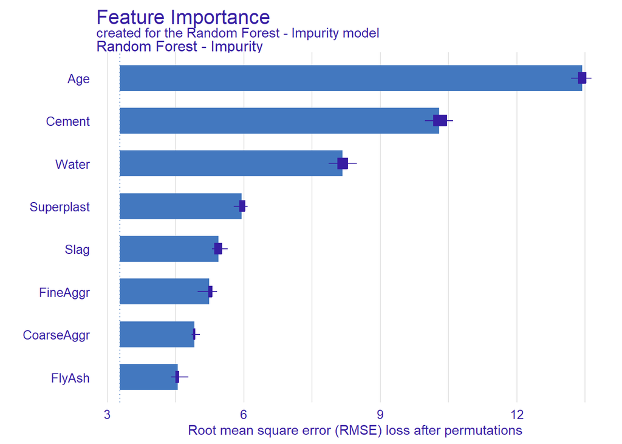

```r
plot(importance)
```

```r
# (b) Partial Dependence Plots for each explanatory variable
pdp <- model_profile(explainer)
print(pdp)
```

```
## Top profiles    :
##      _vname_                  _label_    _x_   _yhat_ _ids_
## 1     FlyAsh Random Forest - Impurity 0.0000 38.33015     0
## 2       Slag Random Forest - Impurity 0.0000 35.33763     0
## 3 Superplast Random Forest - Impurity 0.0000 35.46101     0
## 4       Slag Random Forest - Impurity 0.0110 35.35686     0
## 5        Age Random Forest - Impurity 1.0000 22.65276     0
## 6 Superplast Random Forest - Impurity 1.8334 36.05861     0
```

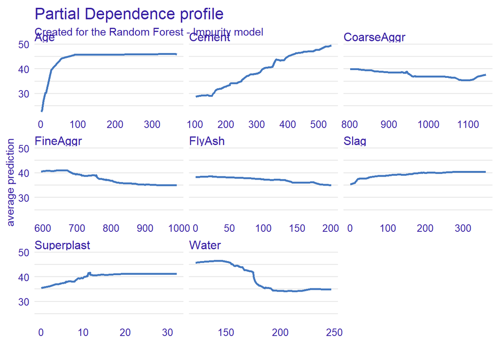

```r
plot(pdp)
```

```r
# (c) Local (Conditional) Dependence Plots
# Example: First observation in the test set
local_profile <- predict_profile(explainer, new_observation = test_set[1, -ncol(test_set)])
print(local_profile)
```

```
## Top profiles    :
##     Cement Slag FlyAsh Water Superplast CoarseAggr FineAggr Age   _yhat_
## 8   102.00   95      0   228          0        932      594  28 32.43800
## 8.1 106.38   95      0   228          0        932      594  28 32.74313
## 8.2 110.76   95      0   228          0        932      594  28 32.80066
## 8.3 115.14   95      0   228          0        932      594  28 33.20966
## 8.4 119.52   95      0   228          0        932      594  28 33.22060
## 8.5 123.90   95      0   228          0        932      594  28 33.22060
##     _vname_ _ids_                  _label_
## 8    Cement     8 Random Forest - Impurity
## 8.1  Cement     8 Random Forest - Impurity
## 8.2  Cement     8 Random Forest - Impurity
## 8.3  Cement     8 Random Forest - Impurity
## 8.4  Cement     8 Random Forest - Impurity
## 8.5  Cement     8 Random Forest - Impurity
##
##
## Top observations:
##   Cement Slag FlyAsh Water Superplast CoarseAggr FineAggr Age   _yhat_
## 8    380   95      0   228          0        932      594  28 41.10353
##                    _label_ _ids_
## 8 Random Forest - Impurity     1
```

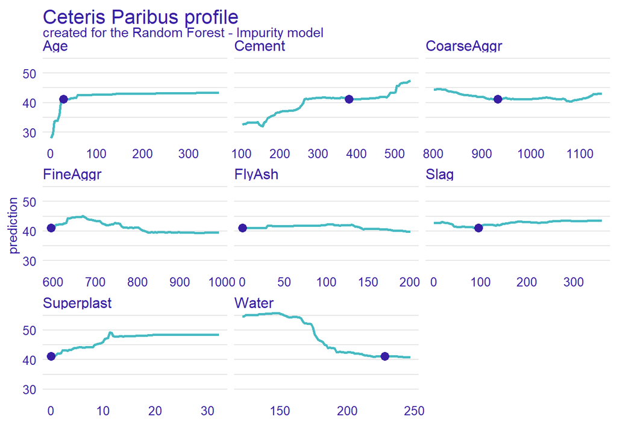

```r
plot(local_profile)
```

**5. Local explainers with library DALEX**

Choose two instances in the the test set, the prediction for which we want to explain: • The data with the lowest value in Strength. • The data with the largest value in Strength. For these two instances, do the following tasks for the fitted random forest. a. Explain the predictions using SHAP. b. Explain the predictions using Break-down plots. c. Explain the predictions using LIME. d. Do the Individual conditional expectation (ICE) plot, or ceteris paribus plot e. Plot in one graphic the Individual conditional expectation (ICE) plot for variable Age for eachcase in the test sample. Add the global Partial Depedence Plot

Identifying the instances

```r
lowest_strength <- test_set[which.min(test_set$Strength), ]
highest_strength <- test_set[which.max(test_set$Strength), ]

lowest_strength
```

```
##     Cement Slag FlyAsh Water Superplast CoarseAggr FineAggr Age Strength
## 669    153  102      0   192          0        888    943.1   3 4.782206
```

```r
highest_strength
```

```
##     Cement  Slag FlyAsh Water Superplast CoarseAggr FineAggr Age Strength
## 154  323.7 282.8      0 183.8       10.3      942.7    659.9  56 80.19985
```

1. Explain the predictions using SHAP

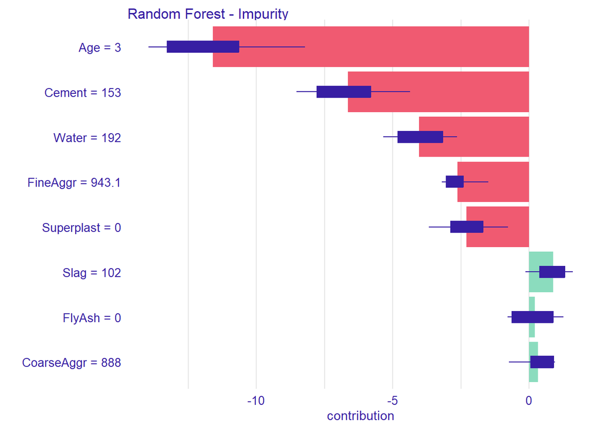

```r
# SHAP lowest Strength instance
bd_rf_low <- predict_parts(explainer = explainer,
                           new_observation = lowest_strength,
                           type = "shap")
plot(bd_rf_low)
```

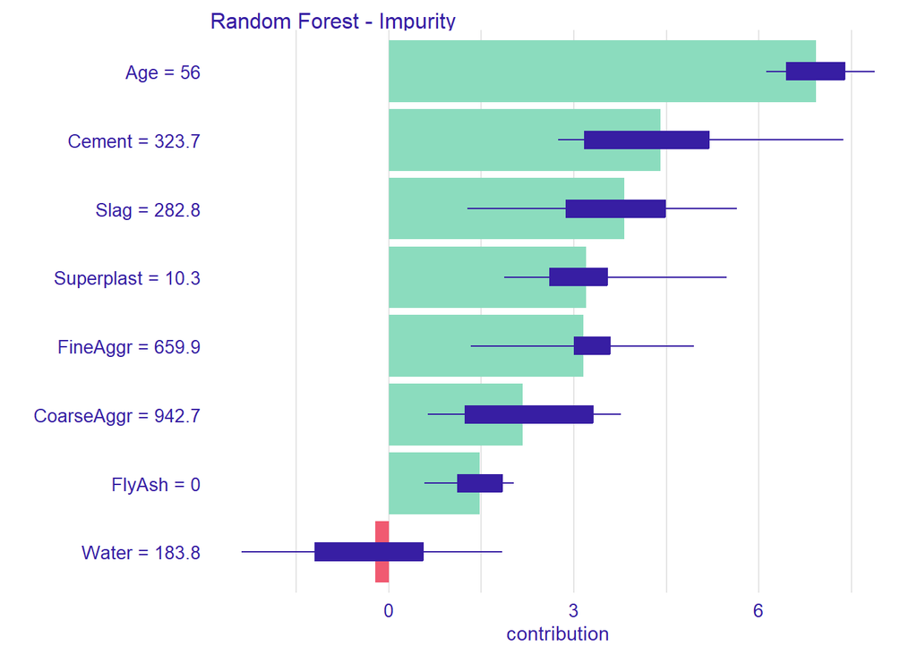

```r
# SHAP highest Strength instance
bd_rf_high <- predict_parts(explainer = explainer,
                            new_observation = highest_strength,
                            type = "shap")
plot(bd_rf_high)
```

2. Explain the predictions using Break-down plots.

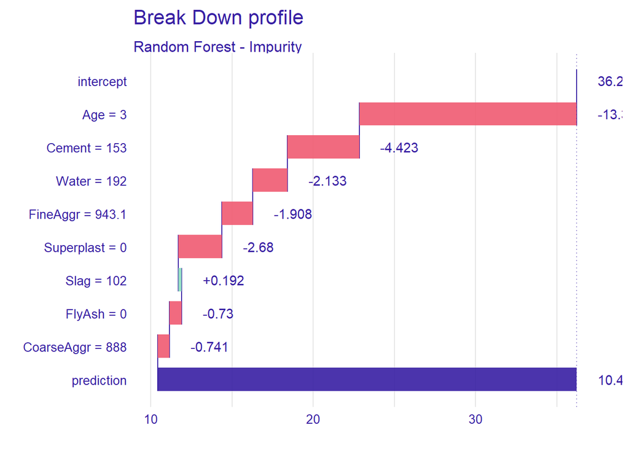

```r
# Break-down lowest Strength instance
bd_rf_low <- predict_parts(explainer = explainer,
                           new_observation = lowest_strength,
                           type = "break_down")
plot(bd_rf_low, max_features = 11)
```

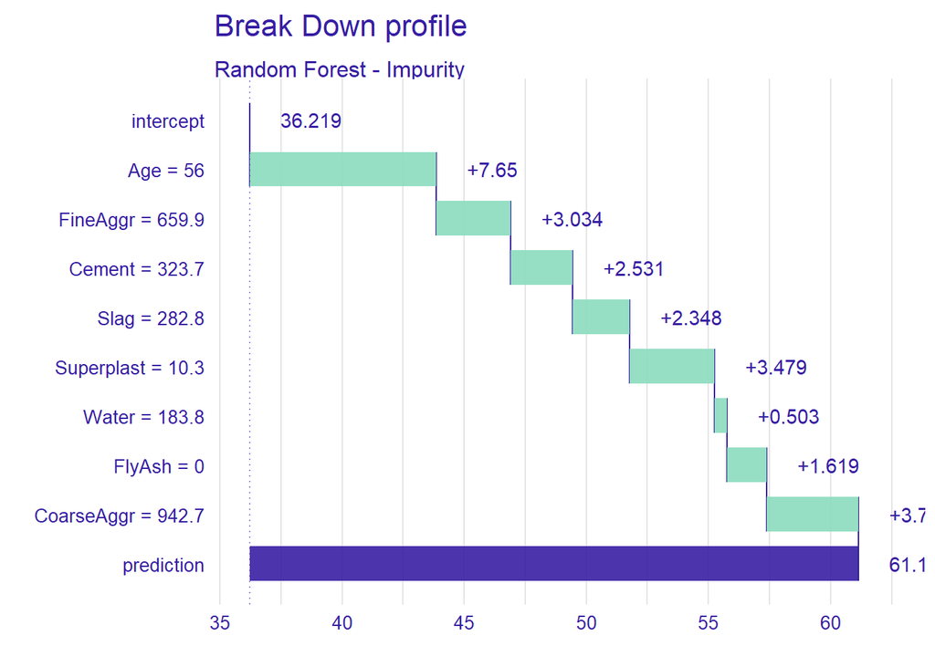

```r
# Break-down highest Strength instance
bd_rf_high <- predict_parts(explainer = explainer,
                            new_observation = highest_strength,
                            type = "break_down")
plot(bd_rf_high, max_features = 11)
```

3. Explain the predictions using LIME

```r
# install.packages("remotes")
# remotes::install_github("modeloriented/localmodel")
```

```r
library(DALEXtra)
library(localModel)
```

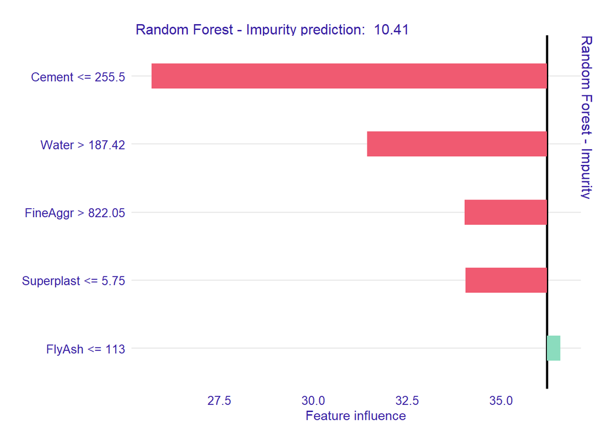

```r
# LIME lowest Strength instance
lime_rf_low <- predict_surrogate(explainer = explainer,
                                 new_observation = lowest_strength,
                                 type = "localModel")
plot(lime_rf_low)
```

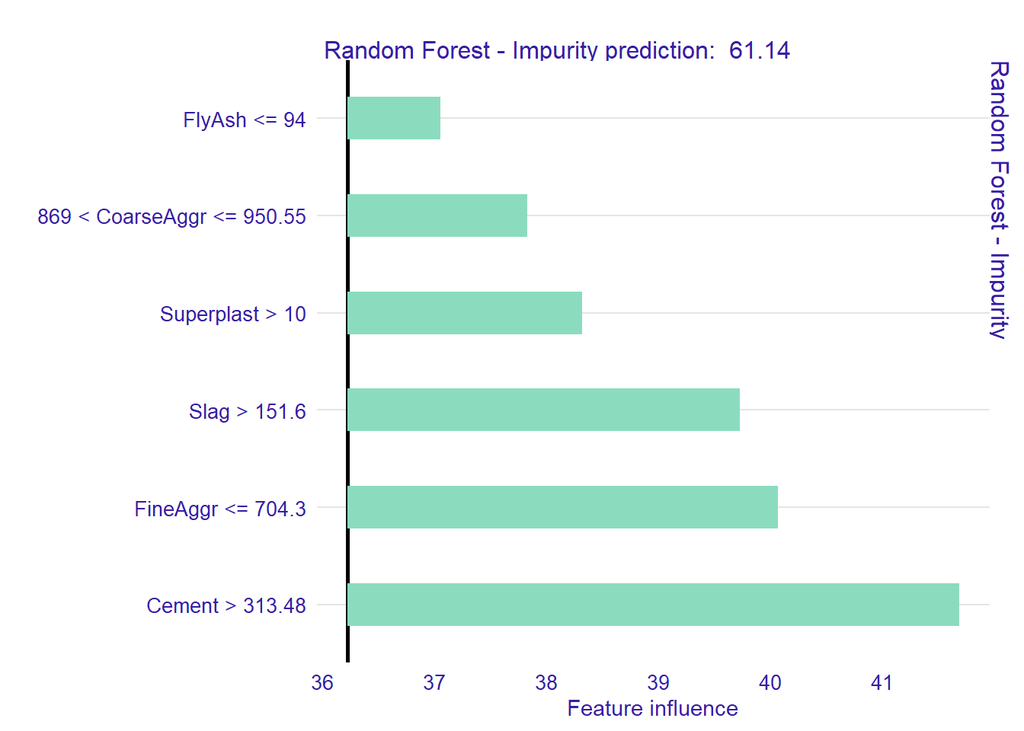

```r
# LIME highest Strength instance
lime_rf_high <- predict_surrogate(explainer = explainer,
                                  new_observation = highest_strength,
                                  type = "localModel")
plot(lime_rf_high)
```

d. Do the Individual conditional expectation (ICE) plot, or ceteris paribus plot

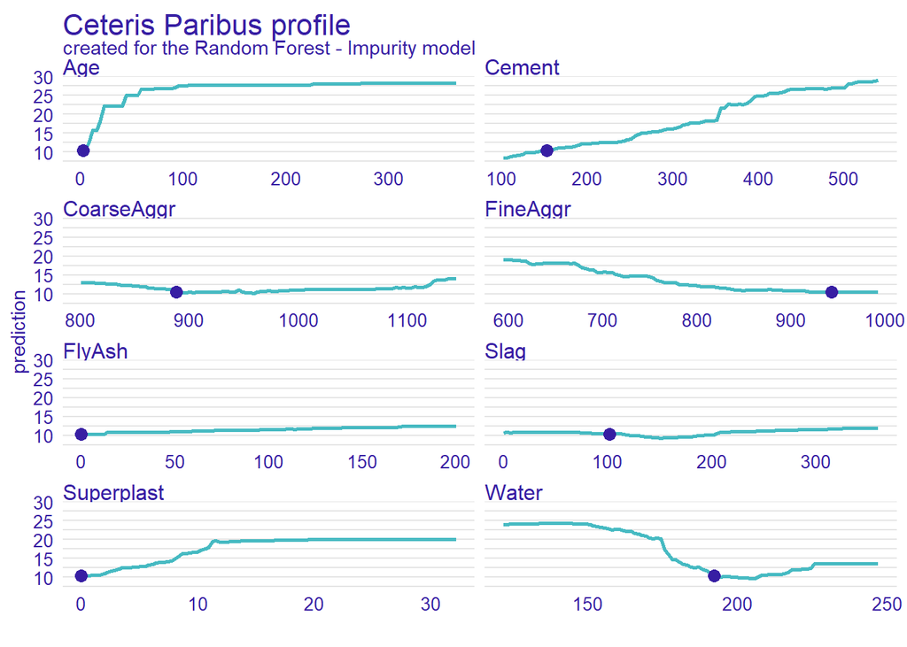

```r
# ICE lowest Strength instance
cp_rf_low <- predict_profile(explainer = explainer,
                             new_observation = lowest_strength)
plot(cp_rf_low, facet_ncol = 2)
```